# Explore and Visualize a Dataset with Python

数据探索及可视化(Seaborn)

[figure not shown]

*Photo by [Léonard Cotte](https://unsplash.com/@ettocl) on [Unsplash](https://unsplash.com/)*

目标：

```
- 数据组合

- 探索分析数据

- 使用图表📈对数据和分析结果可视化
```

#### 情景假设

*''' You are tasked with figuring out how to increase your sales team’s performance. In our hypothetical situation, potential customers have rather spontaneous demand. When this happens, your sales team puts an order lead in the system. Your sales reps then try to get set up a meeting that occurs around the time the order lead was noticed. Sometimes before, sometimes after. Your sales reps have an expense budget and always combine the meeting with a meal for which they pay. The sales reps expense their costs and hand the invoices to the accounting team for processing. After the potential customer has decided whether or not they want to go with your offer, your diligent sales reps track whether or not the order lead converted into a sale.'''*

三个可用数据集：

- order_leads
- sales_team
- invoices

#### 使用的Python库及图表风格设置

```python
import json
import pandas as pd
import numpy as np
%matplotlib inline
import matplotlib.pyplot as plt
import seaborn as sns
```

```python
sns.set(
    font_scale = 1.5,
    style = 'whitegrid',
    rc = {'figure.figsize':(20,7)}
)
```

#### 载入数据集

```python
sales_team = pd.read_csv('./sales_team.csv')
order_leads = pd.read_csv('./order_leads.csv')
invoices = pd.read_csv('./invoices.csv')
```

```python
sales_team.head(2)
```

|  | Sales Rep | Sales Rep Id | Company Name | Company Id |
| --- | --- | --- | --- | --- |
| 0 | William Taylor | ZTZA0ZLYZR85PTUJ | Melancholy Social-Role | D0AUXPP07H6AVSGD |
| 1 | William Taylor | ZTZA0ZLYZR85PTUJ | Pee-Wee Pigeon | TJW99R4RWH02INII |

```python
order_leads.head(2)
```

|  | Order Id | Company Id | Company Name | Date | Order Value | Converted |
| --- | --- | --- | --- | --- | --- | --- |
| 0 | HZSXLI1IS9RGABZW | D0AUXPP07H6AVSGD | Melancholy Social-Role | 2017-10-13 | 6952 | 0 |
| 1 | 582WPS3OW8T6YT0R | D0AUXPP07H6AVSGD | Melancholy Social-Role | 2017-09-02 | 7930 | 0 |

```python
invoices.head(2)
```

|  | Meal Id | Company Id | Date of Meal | Participants | Meal Price |
| --- | --- | --- | --- | --- | --- |
| 0 | QBGU1W8BRZZFHYUZ | D0AUXPP07H6AVSGD | 2017-10-09 21:00:00 | ['Violet Medina'] | 598.0 |
| 1 | QFNO07V7P3BTJSDK | D0AUXPP07H6AVSGD | 2018-06-07 07:00:00 | ['Connie Harper'] | 89.0 |

#### Ok,让我们开始探索吧！

##### 让我们看一下总体转化率的趋势

```python
 _ = order_leads.set_index(pd.DatetimeIndex(order_leads.Date)).groupby(
     pd.Grouper(freq='D')
 )['Converted'].mean()
```

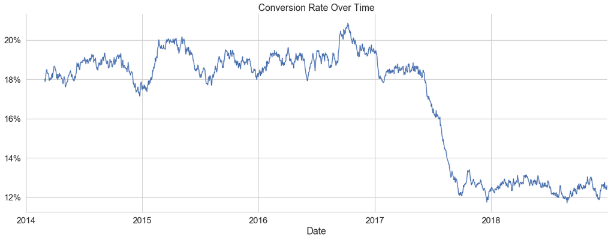

```python
ax = _.rolling(60).mean().plot(figsize=(20,7),title="Conversion Rate Over Time")

vals = ax.get_yticks()
ax.set_yticklabels(['{:,.0f}%'.format(x*100) for x in vals])
sns.despine()
```

2017年初总体形势开始出现下滑，与销售总监确认后发现，原来是那段时期有竞争对手🐺进入了市场。

在上面的代码中，

- 我们在$order\_leads.Data$上使用了$pd.DateTimeIndex$方法，使得日期作为索引,
- 然后我们使用了$pd.Grouped(freq='D')$方法，以天为单位，对数据进行了分组。当然啦，你以可以使用其他频率关键字，比如$W(week),M(month),Q(quarter),Y(year)$,
- 我们计算了每一天“Converted”的平均值，它代表每一天的转化率,
- 我们使用$.rolling(60).mean()$方法得到了60天的滑动平均值.

##### 销售代表们的业绩分布怎么样呢？😈

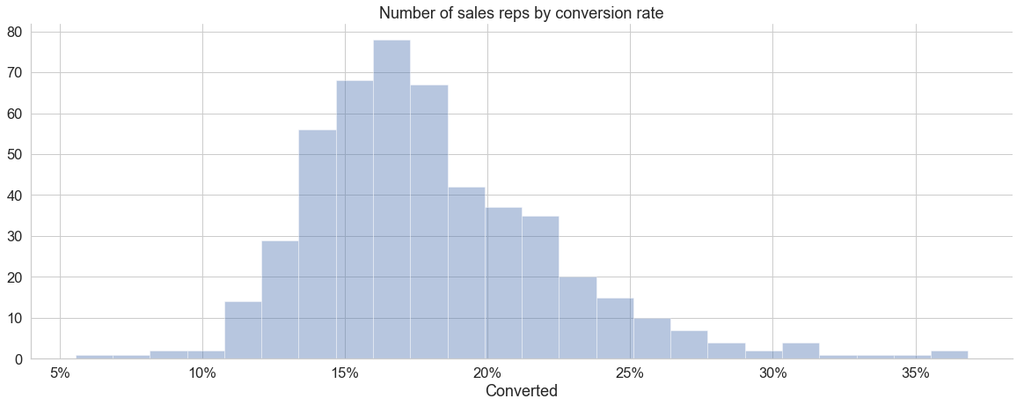

```python
orders_with_sales_team = pd.merge(order_leads,sales_team,on=['Company Id','Company Name'])

sns.set(
    font_scale=1.5,
    style='whitegrid',
    rc={'figure.figsize':(20,7)}
)

ax = sns.distplot(orders_with_sales_team.groupby('Sales Rep Id')['Converted'].mean(),kde=False)
vals = ax.get_xticks()
ax.set_xticklabels(['{:,.0f}%'.format(x*100) for x in vals])
ax.set_title('Number of sales reps by conversion rate')
sns.despine()
```

Wow,看起来销售代表间的差距还是很大的。

在上面的代码中，我们使用了$sns.distplot$绘制了数据分布图。

##### 账户数量的影响

我们知道，在$sales\_team$数据中，不是所有的销售代表都有相同数目的账户，这有什么影响呢？Let's Check！✨

```python
def vertical_mean_line(x,**kwargs):
    ls = {'0':'-','1':'--'}
    plt.axvline(x.mean(),linestyle=ls[kwargs.get("label","0")],
               color = kwargs.get("color","r"))
    txkw = dict(size=15,color=kwargs.get("color","r"))
    tx = "mean: {:,.1f}%\n(std: {:,.1f}%)".format(x.mean()*100,x.std()*100)
    label_x_pos_adjustment = 0.015
    label_y_pos_adjustment = 20
    plt.text(x.mean()+label_x_pos_adjustment,label_y_pos_adjustment,tx,**txkw)
```

```python
sns.set(
    font_scale=1.5,
    style='whitegrid'
)
```

```python
_ = orders_with_sales_team.groupby('Sales Rep Id').agg({
    'Converted':np.mean,
    'Company Id':pd.Series.nunique
})
```

```python
_.columns = ['conversion rate','number of accounts']
```

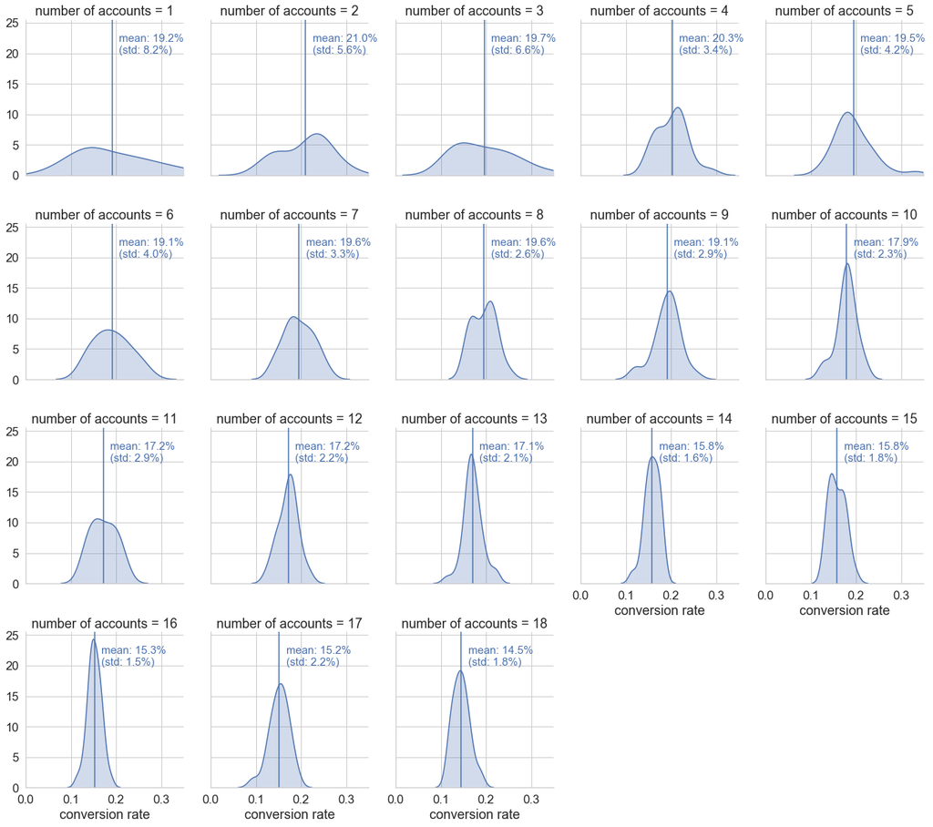

```python
g = sns.FacetGrid(_,col="number of accounts",height=4,aspect=0.9,col_wrap=5)
g.map(sns.kdeplot,'conversion rate',shade=True)
g.set(xlim=(0,0.35))
g.map(vertical_mean_line,'conversion rate')
```

我们可以看到，转户率似乎与分配给销售代表的账户数量成反比，这是合理的，毕竟每个代表拥有的账户越多，他花在每个账户上的时间就越少。

##### Effect of meals

```python
invoices.head(2)
```

|  | Meal Id | Company Id | Date of Meal | Participants | Meal Price |
| --- | --- | --- | --- | --- | --- |
| 0 | QBGU1W8BRZZFHYUZ | D0AUXPP07H6AVSGD | 2017-10-09 21:00:00 | ['Violet Medina'] | 598.0 |
| 1 | QFNO07V7P3BTJSDK | D0AUXPP07H6AVSGD | 2018-06-07 07:00:00 | ['Connie Harper'] | 89.0 |

我们有吃饭的日期和时间，让我们快速看一下时间分布：

```python
invoices['Date of Meal'] = pd.to_datetime(invoices['Date of Meal'])
invoices['Date of Meal'].dt.time.value_counts().sort_index()
```

```
07:00:00    5536
08:00:00    5613
09:00:00    5473
12:00:00    5614
13:00:00    5412
14:00:00    5633
20:00:00    5528
21:00:00    5534
22:00:00    5647
Name: Date of Meal, dtype: int64
```

我们可以可以按照早餐，午餐，晚餐划分总结一下：

```python
invoices['Type of Meal'] = pd.cut(
    invoices['Date of Meal'].dt.hour,
    bins=[0,10,15,24],
    labels = ['breakfast','lunch','dinner']
)
```

```python
invoices.head(2)
```

|  | Meal Id | Company Id | Date of Meal | Participants | Meal Price | Type of Meal |
| --- | --- | --- | --- | --- | --- | --- |
| 0 | QBGU1W8BRZZFHYUZ | D0AUXPP07H6AVSGD | 2017-10-09 21:00:00 | ['Violet Medina'] | 598.0 | dinner |
| 1 | QFNO07V7P3BTJSDK | D0AUXPP07H6AVSGD | 2018-06-07 07:00:00 | ['Connie Harper'] | 89.0 | breakfast |

$invoices['participants']$中的参与者信息是字符串类型，我们要统计参与者数量首先应该将其转化为合法的JSON类型。

```python
def replace(x):
    return x.replace("\n ",",").replace("' '","','").replace("'",'"')

invoices['Participants'] = invoices['Participants'].apply(lambda x:replace(x))
invoices['Number Participants'] = invoices['Participants'].apply(lambda x:len(json.loads(x)))
```

```python
invoices.head(2)
```

|  | Meal Id | Company Id | Date of Meal | Participants | Meal Price | Type of Meal | Number Participants |
| --- | --- | --- | --- | --- | --- | --- | --- |
| 0 | QBGU1W8BRZZFHYUZ | D0AUXPP07H6AVSGD | 2017-10-09 21:00:00 | ["Violet Medina"] | 598.0 | dinner | 1 |
| 1 | QFNO07V7P3BTJSDK | D0AUXPP07H6AVSGD | 2018-06-07 07:00:00 | ["Connie Harper"] | 89.0 | breakfast | 1 |

现在开始合并数据吧！

```python
# combine order_leads with invoice data
orders_with_invoices = pd.merge(order_leads,invoices,how='left',on='Company Id')
```

```python
orders_with_invoices.head(10)
```

|  | Order Id | Company Id | Company Name | Date | Order Value | Converted | Meal Id | Date of Meal | Participants | Meal Price | Type of Meal | Number Participants |
| --- | --- | --- | --- | --- | --- | --- | --- | --- | --- | --- | --- | --- |
| 0 | HZSXLI1IS9RGABZW | D0AUXPP07H6AVSGD | Melancholy Social-Role | 2017-10-13 | 6952 | 0 | QBGU1W8BRZZFHYUZ | 2017-10-09 21:00:00 | ["Violet Medina"] | 598.0 | dinner | 1 |
| 1 | HZSXLI1IS9RGABZW | D0AUXPP07H6AVSGD | Melancholy Social-Role | 2017-10-13 | 6952 | 0 | QFNO07V7P3BTJSDK | 2018-06-07 07:00:00 | ["Connie Harper"] | 89.0 | breakfast | 1 |
| 2 | HZSXLI1IS9RGABZW | D0AUXPP07H6AVSGD | Melancholy Social-Role | 2017-10-13 | 6952 | 0 | ZDQ15BT9LLWUQ6M8 | 2014-12-18 20:00:00 | ["Arthur Lopez"] | 295.0 | dinner | 1 |
| 3 | HZSXLI1IS9RGABZW | D0AUXPP07H6AVSGD | Melancholy Social-Role | 2017-10-13 | 6952 | 0 | GL1ZVDU85Q9EO4TA | 2018-03-05 12:00:00 | ["Violet Medina","Arthur Lopez"] | 193.0 | lunch | 2 |
| 4 | HZSXLI1IS9RGABZW | D0AUXPP07H6AVSGD | Melancholy Social-Role | 2017-10-13 | 6952 | 0 | 42GWYA5XD8NVINY3 | 2017-06-17 08:00:00 | ["Arthur Lopez"] | 348.0 | breakfast | 1 |
| 5 | HZSXLI1IS9RGABZW | D0AUXPP07H6AVSGD | Melancholy Social-Role | 2017-10-13 | 6952 | 0 | OL3R3VYGQ8QAYRHO | 2018-07-01 07:00:00 | ["Violet Medina"] | 72.0 | breakfast | 1 |
| 6 | HZSXLI1IS9RGABZW | D0AUXPP07H6AVSGD | Melancholy Social-Role | 2017-10-13 | 6952 | 0 | 53412BJ5LWCXV4NM | 2015-06-30 14:00:00 | ["Arthur Lopez"] | 43.0 | lunch | 1 |
| 7 | HZSXLI1IS9RGABZW | D0AUXPP07H6AVSGD | Melancholy Social-Role | 2017-10-13 | 6952 | 0 | 919XOCXA1I0XX2GK | 2016-05-25 09:00:00 | ["Connie Harper","Arthur Lopez"] | 50.0 | breakfast | 2 |
| 8 | HZSXLI1IS9RGABZW | D0AUXPP07H6AVSGD | Melancholy Social-Role | 2017-10-13 | 6952 | 0 | 75NPW6ZXG0O6CB5Y | 2017-07-04 12:00:00 | ["Violet Medina"] | 360.0 | lunch | 1 |
| 9 | HZSXLI1IS9RGABZW | D0AUXPP07H6AVSGD | Melancholy Social-Role | 2017-10-13 | 6952 | 0 | G0LADRNUFY7ERP8X | 2014-06-08 21:00:00 | ["Connie Harper"] | 91.0 | dinner | 1 |

```python
# calculate days between order leads and invocies
orders_with_invoices['Days of meal before order'] = (
    pd.to_datetime(orders_with_invoices['Date']) - orders_with_invoices['Date of Meal']
).dt.days
```

```python
orders_with_invoices.head(10)
```

|  | Order Id | Company Id | Company Name | Date | Order Value | Converted | Meal Id | Date of Meal | Participants | Meal Price | Type of Meal | Number Participants | Days of meal before order |
| --- | --- | --- | --- | --- | --- | --- | --- | --- | --- | --- | --- | --- | --- |
| 0 | HZSXLI1IS9RGABZW | D0AUXPP07H6AVSGD | Melancholy Social-Role | 2017-10-13 | 6952 | 0 | QBGU1W8BRZZFHYUZ | 2017-10-09 21:00:00 | ["Violet Medina"] | 598.0 | dinner | 1 | 3 |
| 1 | HZSXLI1IS9RGABZW | D0AUXPP07H6AVSGD | Melancholy Social-Role | 2017-10-13 | 6952 | 0 | QFNO07V7P3BTJSDK | 2018-06-07 07:00:00 | ["Connie Harper"] | 89.0 | breakfast | 1 | -238 |
| 2 | HZSXLI1IS9RGABZW | D0AUXPP07H6AVSGD | Melancholy Social-Role | 2017-10-13 | 6952 | 0 | ZDQ15BT9LLWUQ6M8 | 2014-12-18 20:00:00 | ["Arthur Lopez"] | 295.0 | dinner | 1 | 1029 |
| 3 | HZSXLI1IS9RGABZW | D0AUXPP07H6AVSGD | Melancholy Social-Role | 2017-10-13 | 6952 | 0 | GL1ZVDU85Q9EO4TA | 2018-03-05 12:00:00 | ["Violet Medina","Arthur Lopez"] | 193.0 | lunch | 2 | -144 |
| 4 | HZSXLI1IS9RGABZW | D0AUXPP07H6AVSGD | Melancholy Social-Role | 2017-10-13 | 6952 | 0 | 42GWYA5XD8NVINY3 | 2017-06-17 08:00:00 | ["Arthur Lopez"] | 348.0 | breakfast | 1 | 117 |
| 5 | HZSXLI1IS9RGABZW | D0AUXPP07H6AVSGD | Melancholy Social-Role | 2017-10-13 | 6952 | 0 | OL3R3VYGQ8QAYRHO | 2018-07-01 07:00:00 | ["Violet Medina"] | 72.0 | breakfast | 1 | -262 |
| 6 | HZSXLI1IS9RGABZW | D0AUXPP07H6AVSGD | Melancholy Social-Role | 2017-10-13 | 6952 | 0 | 53412BJ5LWCXV4NM | 2015-06-30 14:00:00 | ["Arthur Lopez"] | 43.0 | lunch | 1 | 835 |
| 7 | HZSXLI1IS9RGABZW | D0AUXPP07H6AVSGD | Melancholy Social-Role | 2017-10-13 | 6952 | 0 | 919XOCXA1I0XX2GK | 2016-05-25 09:00:00 | ["Connie Harper","Arthur Lopez"] | 50.0 | breakfast | 2 | 505 |
| 8 | HZSXLI1IS9RGABZW | D0AUXPP07H6AVSGD | Melancholy Social-Role | 2017-10-13 | 6952 | 0 | 75NPW6ZXG0O6CB5Y | 2017-07-04 12:00:00 | ["Violet Medina"] | 360.0 | lunch | 1 | 100 |
| 9 | HZSXLI1IS9RGABZW | D0AUXPP07H6AVSGD | Melancholy Social-Role | 2017-10-13 | 6952 | 0 | G0LADRNUFY7ERP8X | 2014-06-08 21:00:00 | ["Connie Harper"] | 91.0 | dinner | 1 | 1222 |

```python
# limit to only meals that are within 5 days of the order
orders_with_invoices = orders_with_invoices[abs(orders_with_invoices['Days of meal before order']) < 5]

orders_with_invoices.head(10)
```

|  | Order Id | Company Id | Company Name | Date | Order Value | Converted | Meal Id | Date of Meal | Participants | Meal Price | Type of Meal | Number Participants | Days of meal before order |
| --- | --- | --- | --- | --- | --- | --- | --- | --- | --- | --- | --- | --- | --- |
| 712602 | M2AQGEDCJ18K4XA6 | 2II1NASXZGEORCH2 | By-Gone Shinbone | 2017-11-24 | 5774 | 1 | SHDCAVQQA8HCFVSL | 2017-11-23 14:00:00 | ["Wendy Meza","John Devine","Raul Bradley","Je... | 427.0 | lunch | 4 | 0 |
| 586294 | E3ZMO1M511QZL8GC | Z17VDRE18MQERYH7 | Eight-Year Wishart | 2018-05-27 | 4998 | 0 | RXZLS3DI1VR4L3EL | 2018-05-26 22:00:00 | ["Jean Hayden","Andrew Moseley"] | 335.0 | dinner | 2 | 0 |
| 200128 | OTB9G4B0BWRK9P6V | GCUZRJ3BMWS9UZM5 | Additional Goad | 2016-05-25 | 5369 | 0 | UY4AKSVRJVSZ8ROZ | 2016-05-24 07:00:00 | ["Johnny Griffin","Stephen Rodriguez","Isaura ... | 515.0 | breakfast | 3 | 0 |
| 103823 | FZNQMXKDOH0NIWU6 | MFP7UB2DQM304QNV | Communist-Inspired Sets | 2015-08-01 | 7692 | 0 | XLCBYDM7K9YCYTPK | 2015-07-31 22:00:00 | ["Betty Crabb"] | 669.0 | dinner | 1 | 0 |
| 398990 | W0XDP91IMZ22XIUO | S2QFKE57NAO9S6C1 | Boon Bones | 2016-06-15 | 2172 | 0 | KHDD2ULT7EHMBSSK | 2016-06-14 12:00:00 | ["Lawrence Palmer"] | 119.0 | lunch | 1 | 0 |
| 837804 | KRMC44FL2JSIQESN | 3M92NTAP8BX2EELR | Nice-Looking Leroy | 2014-12-06 | 1739 | 0 | 8GEHQGQIBR172QDK | 2014-12-05 14:00:00 | ["Leona Evans","Lori Adams"] | 570.0 | lunch | 2 | 0 |
| 103592 | XOBZFTSVYMJSQ3KN | MFP7UB2DQM304QNV | Communist-Inspired Sets | 2014-04-30 | 4837 | 0 | FI3RBMBJBC792JPK | 2014-04-29 13:00:00 | ["Betty Crabb"] | 339.0 | lunch | 1 | 0 |
| 103575 | 40JQMFRB0FO48WU9 | MFP7UB2DQM304QNV | Communist-Inspired Sets | 2014-05-27 | 1053 | 0 | CS3GQG1P4L1P5IUV | 2014-05-26 09:00:00 | ["Betty Crabb"] | 88.0 | breakfast | 1 | 0 |
| 837842 | KMWADPNM8N63OFCV | W89U9GKBADTDKY4L | Leaden Hookworm | 2016-09-13 | 4482 | 0 | QUFMPC3QCWSY9VF9 | 2016-09-12 08:00:00 | ["Quiana Riley","Janie Artrip","William Bixby"] | 318.0 | breakfast | 3 | 0 |
| 303250 | MGCVCEO25EU0C5UY | EFCFLIWYJFXBZK06 | Jacksonian '80'S | 2017-04-29 | 5486 | 0 | KGB0WIT2PAGUFYXN | 2017-04-28 08:00:00 | ["Bradley Early"] | 477.0 | breakfast | 1 | 0 |

```python
# To mnake sure that we don't cross assign meals to multiple orders and therefore create duplicates
# we first sort our data by absolute distance to the orders
orders_with_invoices = orders_with_invoices.loc[
    abs(orders_with_invoices['Days of meal before order']).sort_values().index
]

# keep the first (i.e. closest to sales event) sales order
orders_with_invoices = orders_with_invoices.drop_duplicates(subset=['Order Id'])
```

```python
orders_without_invoices = order_leads[~order_leads['Order Id'].isin(orders_with_invoices['Order Id'].unique())]

orders_with_meals = pd.concat([orders_with_invoices,orders_without_invoices],sort=True)
```

```python
orders_without_invoices.shape,orders_with_meals.shape
```

```
((52103, 6), (100000, 13))
```

现在我们定义一个绘制条形图的函数

```python
def plot_bars(data,x_col,y_col):
    data = data.reset_index()
    sns.set(
        font_scale=1.5,
        style="whitegrid",
        rc={'figure.figsize':(20,7)}
    )
    g = sns.barplot(x=x_col, y=y_col, data=data, color='royalblue')

    for p in g.patches:
        g.annotate(
            format(p.get_height(), '.2%'),
            (p.get_x() + p.get_width() / 2., p.get_height()),
            ha = 'center',
            va = 'center',
            xytext = (0, 10),
            textcoords = 'offset points'
        )

    vals = g.get_yticks()
    g.set_yticklabels(['{:,.0f}%'.format(x*100) for x in vals])

    sns.despine()
```

###### Impact of type of meal

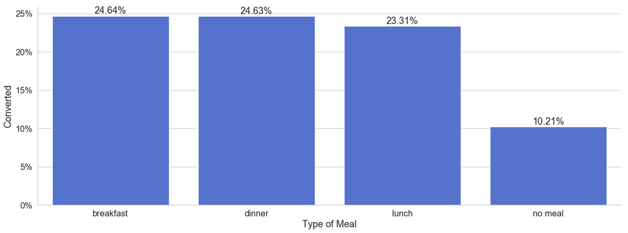

```python
orders_with_meals['Type of Meal'].fillna('no meal',inplace=True)
_ = orders_with_meals.groupby('Type of Meal').agg({'Converted': np.mean})
plot_bars(_,x_col='Type of Meal',y_col='Converted')
```

Wow!看起来吃饭对转化率的影响还是很大的，另外，午餐的转化率似乎略低于早餐或者晚餐。

###### Impact of timing

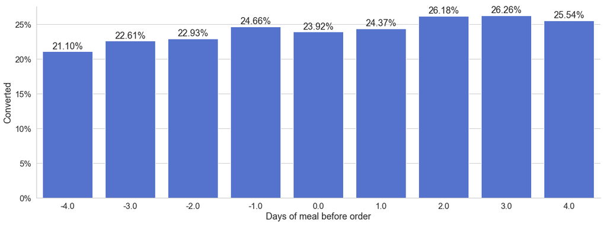

```python
_ = orders_with_meals.groupby(['Days of meal before order']).agg(
    {'Converted': np.mean}
)
plot_bars(data=_,x_col='Days of meal before order',y_col='Converted')
```

负数表示的是吃饭发生在订单导入后。我们可以看到，如果吃饭发生在订单导入前那么对转化率有一个积极的影响，看来销售代表如果事先了解订单的话确实会有优势。

##### Combining it all!

最后，我们使用热力图从多维度同时对数据进行可视化展示。

首先，我们定义一个帮助函数：

```python
def draw_heatmap(data,inner_row, inner_col, outer_row, outer_col, values):
    sns.set(font_scale=1)
    fg = sns.FacetGrid(
        data,
        row=outer_row,
        col=outer_col,
        margin_titles=True
    )

    position = left, bottom, width, height = 1.4, .2, .1, .6
    cbar_ax = fg.fig.add_axes(position)

    fg.map_dataframe(
        draw_heatmap_facet,
        x_col=inner_col,
        y_col=inner_row,
        values=values,
        cbar_ax=cbar_ax,
        vmin=0,
        vmax=.4
    )

    fg.fig.subplots_adjust(right=1.3)
    plt.show()

def draw_heatmap_facet(*args, **kwargs):
    data = kwargs.pop('data')
    x_col = kwargs.pop('x_col')
    y_col = kwargs.pop('y_col')
    values = kwargs.pop('values')
    d = data.pivot(index=y_col, columns=x_col, values=values)
    annot = round(d,4).values
    cmap = sns.color_palette("RdYlGn",30)
    # cmap = sns.color_palette("PuBu",30) alternative color coding
    sns.heatmap(d, **kwargs, annot=annot, center=0, fmt=".1%", cmap=cmap, linewidth=.5)
```

```python
# Aggregate the data a bit
orders_with_meals['Meal Price / Order Value'] = orders_with_meals['Meal Price']/orders_with_meals['Order Value']
orders_with_meals['Meal Price / Order Value'] = pd.qcut(
    orders_with_meals['Meal Price / Order Value']*-1,
    5,
    labels = ['Least Expensive','Less Expensive','Proportional','More Expensive','Most Expensive'][::-1]
)

orders_with_meals['Timing of Meal'] = pd.qcut(
    orders_with_meals['Days of meal before order'],
    3,
    labels = ['After Order','Around Order','Before Order']
)


data = orders_with_meals[orders_with_meals['Type of Meal'] != 'no meal'].groupby(
    ['Timing of Meal','Number Participants','Type of Meal','Meal Price / Order Value']
).agg({'Converted': np.mean}).unstack().fillna(0).stack().reset_index()
```

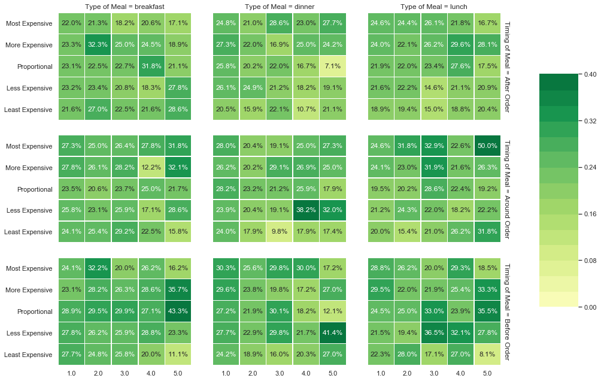

```python
draw_heatmap(
    data=data,
    outer_row='Timing of Meal',
    outer_col='Type of Meal',
    inner_row='Meal Price / Order Value',
    inner_col='Number Participants',
    values='Converted'
)
```

OK，上面的图表呢从四个维度对数据进行了总结：

- Timing of the meal: After Order, Around Order, Before Order (outer rows)
- Type of meal: breakfast, dinner, lunch (outer columns)
- Meal Price / Order Values: Least Expensive, Less Expensive, Proportional, More Expensive, Most Expensive (inner rows)
- Number Participants: 1,2,3,4,5 (inner columns)

图表的颜色分布说明：

- 用餐发生在订单前对应的转化率更高
- 吃晚饭且参与者只有一个时的转化率很高
- 相比于订单价值，昂贵的用餐费用对转化率有积极的影响

#### 结论

- 每个销售代表的拥有的账户不要超过9个（因为此时转化率急剧下降）
- 确保每个订单都有会议/餐点（因为这会让转化率增加一倍）
- 只有一名参与者的晚餐是最奏效的
- 销售代表支付的餐费大约是订单价值的8%到10%
- 时间很关键，销售代表要尽早知道订单即将来到

**Reference**

[how to explore and visualize a dataset with python](https://towardsdatascience.com/how-to-explore-and-visualize-a-dataset-with-python-7da5024900ef)